# resumo_exploratoria

Douglas Silva Alves

2024-02-07

# Apresentação

Este documento foi construído com o objetivo de sintetizar toda a análise exploratória dos dados, o que inclui a caracterização da amostra, assim como, a análise da distribuição das variáveis dependentes do estudo

# Caracterização da amostra

Vamos começar caracterizando a nossa amostra quanto aos dados coletados no screening da pesquisa

## Carregar pacotes

```r
library(statsr)
library(dplyr)
library(ggplot2)
library(readxl)
library(lubridate)
library(tidyr)
library(writexl)
library(kableExtra)
library(knitr)
```

Agora, vamos carregar o banco de dados

## Carregar o nosso banco de dados

```r
dados <- read_excel('D:/Projeto_mestrado/Dissertacao/MastersDissertation/Dados/Quinto processamento/banco_dados_reestruturado.xlsx')
```

## Agora, vamos adicionar mais uma variável no banco de dados, que é o IMC dos sujeitos

```r
dados$IMC <- dados$Massa/dados$Estatura^2
```

## Vamos calcular as proporções das variáveis categóricas

```r
proporcao_sexo <- prop.table(table(dados$Sexo))
proporcao_trabalho <- prop.table(table(dados$Trabalho))
proporcao_escolaridade <- prop.table(table(dados$Escolaridade))
```

Nesta etapa, observou-se que um dos participantes preencheu o nível de escolaridade incorretamente. Contatando este participante (ID 25), foi-se possível saber o seu real nível de escolaridade, portanto, vamos corrigir nos nossos dados

## Corrigir escolaridade (ID 25)

```r
dados$Escolaridade <- ifelse(dados$Escolaridade == "Ensino fundamental incompleto", "Ensino superior completo", dados$Escolaridade)
```

Agora vamos calcular média e intervalo de confiança dos dados contínuos e discretos

## Vamos definir uma função para calcular o intervalo de confiança de 95% em torno da média dos dados

```r
calculo_ic <- function(dados){
  media <- mean(dados)
  z <- 1.96
  dp <- sd(dados)
  rn <- sqrt(length(dados))

  ic_upper <- media + z*(dp/rn)
  ic_lower <- media - z*(dp/rn)

  intervalo_confianca <- c(ic_lower, ic_upper)
  return(intervalo_confianca)
}
```

## Agora vamos calcular média e intervalo de confiança de 95% para cada variável contínua ou discreta

```r
media_idade <- mean(dados$Idade)
ic_idade <- calculo_ic(dados$Idade)

media_estatura <- mean(dados$Estatura)
ic_estatura <- calculo_ic(dados$Estatura)

media_massa <- mean(dados$Massa)
ic_massa <- calculo_ic(dados$Massa)

media_IMC <- mean(dados$IMC)
ic_imc <- calculo_ic(dados$IMC)
```

## Vamos salvar esses intervalos de confiança em apenas uma variável, para podermos utilizá-la na nossa tabela

```r
ics <- c(ic_idade, ic_estatura, ic_massa, ic_imc)
```

## Criar um novo vetor contendo os intervalos de confiança arredondados

```r
intervalos_confianca <- sapply(1:(length(ics)/2), function(i) {
  lower <- ics[i*2-1]
  upper <- ics[i*2]
  paste(round(lower, 2), round(upper, 2), sep = "-")
})
```

## Transformar o vetor em um dataframe

```r
ics_dataframe <- data.frame(matrix(intervalos_confianca, ncol = length(intervalos_confianca), byrow = TRUE))
```

## Agora vamos expressar esses resultados em uma tabela

```r
tabela_esperanca <- data.frame(
  Variavel = c("Idade", "Sexo (M)", "Estatura", "Massa", "IMC", "Trabalho (S)", "Ensino médio completo", "Ensino superior completo", "Pós-graduação completa"),
  Esperanca = c(media_idade, "-", media_estatura, media_massa, media_IMC, "-", "-", "-", "-"),
  IC_95 = c(ics_dataframe$X1, "-", ics_dataframe$X2, ics_dataframe$X3, ics_dataframe$X4, "-", "-", "-", "-"),
  Contagem = c("-", 29, "-", "-", "-", 55, 24, 23, 17),
  Percentual = c("-", 45.3, "-", "-", "-", 85.9, 37.5, 35.9, 26.6)
)
```

## Vamos renomear algumas colunas

```r
colnames(tabela_esperanca)[colnames(tabela_esperanca) == "Variavel"] <- " "
colnames(tabela_esperanca)[colnames(tabela_esperanca) == "IC_95"] <- "Intervalo de confiança de 95%"
```

## Agora vamos gerar a nossa tabela

```r
tabela_esperanca
```

|  | Esperanca | Intervalo de confiança de 95% | Contagem | Percentual |
| --- | --- | --- | --- | --- |
| Idade | 27.703125 | 26.99-28.42 | - | - |
| Sexo (M) | - | - | 29 | 45.3 |
| Estatura | 1.7003125 | 1.69-1.71 | - | - |
| Massa | 73.6875 | 72.05-75.33 | - | - |
| IMC | 25.4141818403693 | 24.93-25.9 | - | - |
| Trabalho (S) | - | - | 55 | 85.9 |
| Ensino médio completo | - | - | 24 | 37.5 |
| Ensino superior completo | - | - | 23 | 35.9 |
| Pós-graduação completa | - | - | 17 | 26.6 |

# Análise da distribuição das VDs

Agora vamos fazer uma análise da distribuição dos nossos dados

A partir daqui utilizaremos scripts em linguagem Python, portanto, precisamos de uma biblioteca nova

```r
library("reticulate")
```

Para as análises a seguir, primeiro trabalharemos com os dados do IPAQ, após a devida remoção dos outliers pelo método de processamento e se baseando em valores de escore-z inferiores ou superiores à 3

## Dados do IPAQ

### Importação das bibliotecas necessárias

```python
import seaborn as sns
import numpy as np
import pandas as pd
import matplotlib.pyplot as plt
from scipy import stats
import statsmodels.api as sm
from scipy.special import ndtri
import matplotlib.lines as mlines
import matplotlib.transforms as mtransforms
import scipy
from distfit import distfit
import pylab as py
from scipy.stats import gamma
import math
```

### Importar banco de dados

```python
dados_sem_outliers_z_score = pd.read_excel('D:/Projeto_mestrado/Dissertacao/MastersDissertation/Dados/Sexto processamento/banco_dados_reestruturado_sem_outliers.xlsx')
```

### Salvar os dados do IPAQ em uma variável, framentado em intensidades de AF, removendo os dados faltantes

```python
leve_IPAQ = list(dados_sem_outliers_z_score['Caminhada_IPAQ_10'].values)
leveipaq_p_quartil_dados = pd.DataFrame(dados_sem_outliers_z_score['Caminhada_IPAQ_10'].dropna())

mod_IPAQ = list(dados_sem_outliers_z_score['Moderada_IPAQ_10'].values)
modipaq_p_quartil_dados = pd.DataFrame(dados_sem_outliers_z_score['Moderada_IPAQ_10'].dropna())

vig_IPAQ = list(dados_sem_outliers_z_score['Vigorosa_IPAQ_10'].values)
vigipaq_p_quartil_dados = pd.DataFrame(dados_sem_outliers_z_score['Vigorosa_IPAQ_10'].dropna())
```

Agora vamos calcular percentis. Os percentis foram calculados, pois de início os qqplots seriam construídos manualmente

### Calcular percentis

```python
### Caminhada IPAQ
df_leve_ipaq = leveipaq_p_quartil_dados.sort_values(by=['Caminhada_IPAQ_10'], ascending=True).reset_index()
df_leve_ipaq['count'] = df_leve_ipaq.index + 1
n_rows = df_leve_ipaq.shape[0]
df_leve_ipaq['percentil_area'] = (df_leve_ipaq['count'])/n_rows
df_leve_ipaq['percentil_teorico'] = ndtri(df_leve_ipaq['percentil_area'])
df_leve_ipaq['percentil_atual'] = (df_leve_ipaq['Caminhada_IPAQ_10'] - df_leve_ipaq['Caminhada_IPAQ_10'].mean())/df_leve_ipaq['Caminhada_IPAQ_10'].std(ddof=0)


### Moderada IPAQ
df_mod_ipaq = modipaq_p_quartil_dados.sort_values(by=['Moderada_IPAQ_10'], ascending=True).reset_index()
df_mod_ipaq['count'] = df_mod_ipaq.index + 1
n_rows = df_mod_ipaq.shape[0]
df_mod_ipaq['percentil_area'] = (df_mod_ipaq['count'])/n_rows
df_mod_ipaq['percentil_teorico'] = ndtri(df_mod_ipaq['percentil_area'])
df_mod_ipaq['percentil_atual'] = (df_mod_ipaq['Moderada_IPAQ_10'] - df_mod_ipaq['Moderada_IPAQ_10'].mean())/df_mod_ipaq['Moderada_IPAQ_10'].std(ddof=0)


### Vigorosa IPAP
df_vig_ipaq = vigipaq_p_quartil_dados.sort_values(by=['Vigorosa_IPAQ_10'], ascending=True).reset_index()
df_vig_ipaq['count'] = df_vig_ipaq.index + 1
n_rows = df_vig_ipaq.shape[0]
df_vig_ipaq['percentil_area'] = (df_vig_ipaq['count'])/n_rows
df_vig_ipaq['percentil_teorico'] = ndtri(df_vig_ipaq['percentil_area'])
df_vig_ipaq['percentil_atual'] = (df_vig_ipaq['Vigorosa_IPAQ_10'] - df_vig_ipaq['Vigorosa_IPAQ_10'].mean())/df_vig_ipaq['Vigorosa_IPAQ_10'].std(ddof=0)
```

Agora vamos testar algumas distribuições de probabilidade por bruteforce, tentando identificar quais possivelmente aderem melhor aos nossos dados, com o objetivo de ajustar essas distribuições nos modelos mistos que construiremos

### Testar distribuições de probabilidade por bruteforce

#### Caminhada IPAQ

```python
dist = distfit(alpha=0.05, smooth=10)

a = np.array(leveipaq_p_quartil_dados)

caminhada_fit = dist.fit_transform(a)
```

```python
best_distr = dist.model
```

```python
dist.summary
```

```
##           name     score            loc  ... bootstrap_score bootstrap_pass    color
## 0     loggamma       0.0 -159608.538114  ...               0           None  #e41a1c
## 1         norm       0.0      315.11032  ...               0           None  #e41a1c
## 2     dweibull  0.000003          190.0  ...               0           None  #377eb8
## 3      uniform  0.000003           10.0  ...               0           None  #4daf4a
## 4            t  0.000004     203.460036  ...               0           None  #984ea3
## 5      lognorm  0.000004           10.0  ...               0           None  #ff7f00
## 6   genextreme  0.000004      67.268444  ...               0           None  #ffff33
## 7        expon  0.000006           10.0  ...               0           None  #a65628
## 8        gamma  0.000006           10.0  ...               0           None  #f781bf
## 9       pareto  0.000007   -2724.009614  ...               0           None  #999999
## 10        beta  0.000009           10.0  ...               0           None  #999999
##
## [11 rows x 10 columns]
```

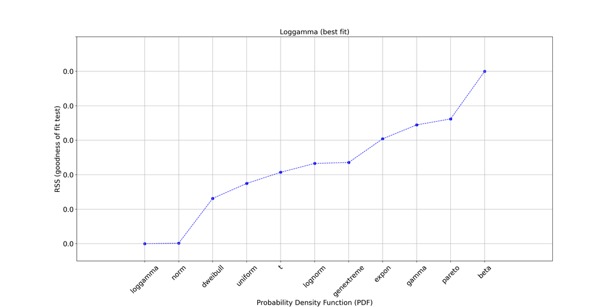

```python
dist.plot_summary()
```

Com base na análise acima, temos como distribuições candidatas para o nosso modelo misto, as distribuições normal e loggamma

#### Moderada IPAQ

```python
dist = distfit(alpha=0.05, smooth=10)

b = np.array(modipaq_p_quartil_dados)


moderada_fit = dist.fit_transform(b)
```

```python
best_distr = dist.model
```

```python
dist.summary
```

```
##           name     score            loc  ... bootstrap_score bootstrap_pass    color
## 0     loggamma       0.0 -125735.355335  ...               0           None  #e41a1c
## 1         norm       0.0     360.505338  ...               0           None  #e41a1c
## 2     dweibull  0.000001     272.963707  ...               0           None  #377eb8
## 3         beta  0.000001           10.0  ...               0           None  #4daf4a
## 4      uniform  0.000002           10.0  ...               0           None  #984ea3
## 5            t  0.000002     264.437984  ...               0           None  #ff7f00
## 6      lognorm  0.000003           10.0  ...               0           None  #ffff33
## 7   genextreme  0.000003      10.336187  ...               0           None  #a65628
## 8       pareto  0.000004           10.0  ...               0           None  #f781bf
## 9        expon  0.000004           10.0  ...               0           None  #999999
## 10       gamma  0.000006           10.0  ...               0           None  #999999
##
## [11 rows x 10 columns]
```

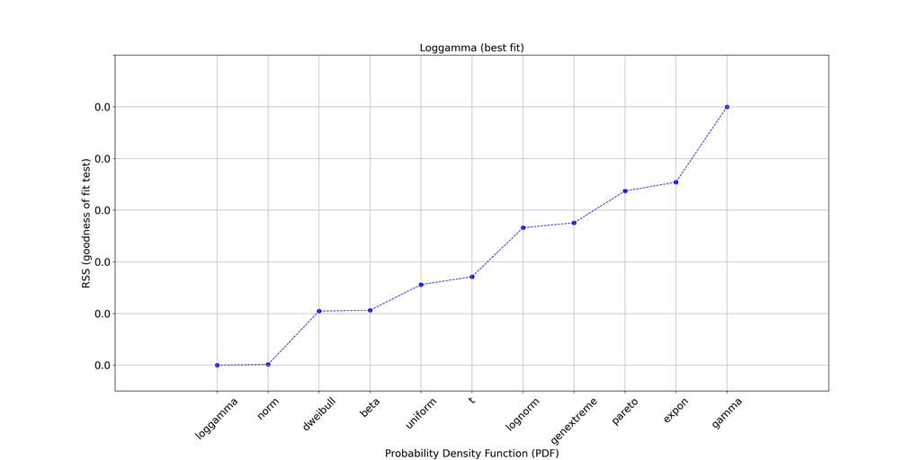

```python
dist.plot_summary()
```

Com base na análise acima, temos como distribuições candidatas para o nosso modelo misto, as distribuições normal e loggamma

#### Vigorosa IPAQ

```python
dist = distfit(alpha=0.05, smooth=10)

c = np.array(vigipaq_p_quartil_dados)


vigorosa_fit = dist.fit_transform(c)
```

```python
best_distr = dist.model
```

```python
dist.summary
```

```
##           name     score           loc  ... bootstrap_score bootstrap_pass    color
## 0     loggamma  0.000002  -59258.32236  ...               0           None  #e41a1c
## 1         norm  0.000002    129.993056  ...               0           None  #e41a1c
## 2      uniform  0.000008          10.0  ...               0           None  #377eb8
## 3         beta  0.000009          10.0  ...               0           None  #4daf4a
## 4     dweibull  0.000011          70.0  ...               0           None  #984ea3
## 5   genextreme  0.000011     10.206128  ...               0           None  #ff7f00
## 6      lognorm  0.000013          10.0  ...               0           None  #ffff33
## 7            t  0.000018          10.0  ...               0           None  #a65628
## 8       pareto  0.000035 -8589934582.0  ...               0           None  #f781bf
## 9        expon  0.000035          10.0  ...               0           None  #999999
## 10       gamma  0.000037          10.0  ...               0           None  #999999
##
## [11 rows x 10 columns]
```

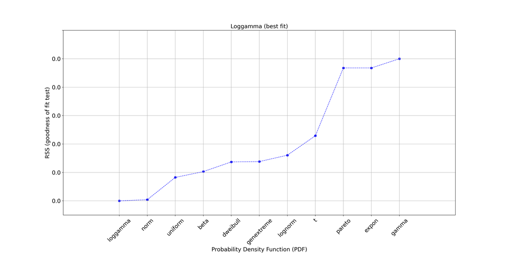

```python
dist.plot_summary()
```

Com base na análise acima, temos como distribuições candidatas para o nosso modelo misto, as distribuições normal e loggamma

Agora, vamos construir subplots com um gráfico quantil-quantil, para analisarmos melhor as possíveis distribuições de probabilidade para os nossos modelos

#### Caminhada IPAQ

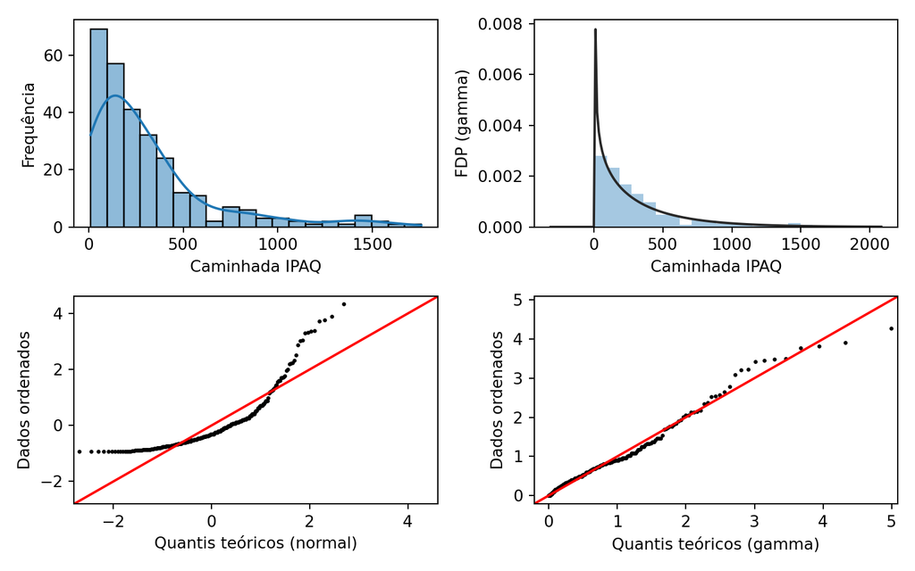

```python
fig, ((ax1,ax2), (ax3,ax4)) = plt.subplots(nrows = 2, ncols = 2, figsize=(8,5), sharey=False)

sns.histplot(leve_IPAQ, kde=True, ax=ax1)
ax1.set_xlabel('Caminhada IPAQ')
sns.distplot(leve_IPAQ, fit=stats.gamma, kde=False, ax=ax2)
ax2.set_xlabel('Caminhada IPAQ')
ax1.set_ylabel('Frequência')
ax2.set_ylabel('FDP (gamma)')

pp = sm.ProbPlot(df_leve_ipaq.Caminhada_IPAQ_10, dist=scipy.stats.distributions.norm, fit=True)
qq = pp.qqplot(marker='.', markerfacecolor='k', markeredgecolor='k', markersize=3, ax=ax3)
sm.qqline(qq.axes[2], line='45')
ax3.set_ylabel('Dados ordenados')
ax3.set_xlabel('Quantis teóricos (normal)')
pp = sm.ProbPlot(df_leve_ipaq.Caminhada_IPAQ_10, dist=stats.gamma, fit=True)
qq = pp.qqplot(marker='.', markerfacecolor='k', markeredgecolor='k', markersize=3, ax=ax4)
sm.qqline(qq.axes[3], line='45')
ax4.set_ylabel('Dados ordenados')
ax4.set_xlabel('Quantis teóricos (gamma)')


plt.rcParams['axes.labelsize']=12
plt.rcParams['axes.titlesize']=12


plt.tight_layout()
#plt.savefig('D:/Projeto_mestrado/Dissertacao/MastersDissertation/Análise exploratória/Distribuição das VDs/Gráficos/distribuicao_caminhada_ipaq_sem_outliers_z_score.png', bbox_inches='tight', dpi = 300)
plt.show()
```

#### Moderada IPAQ

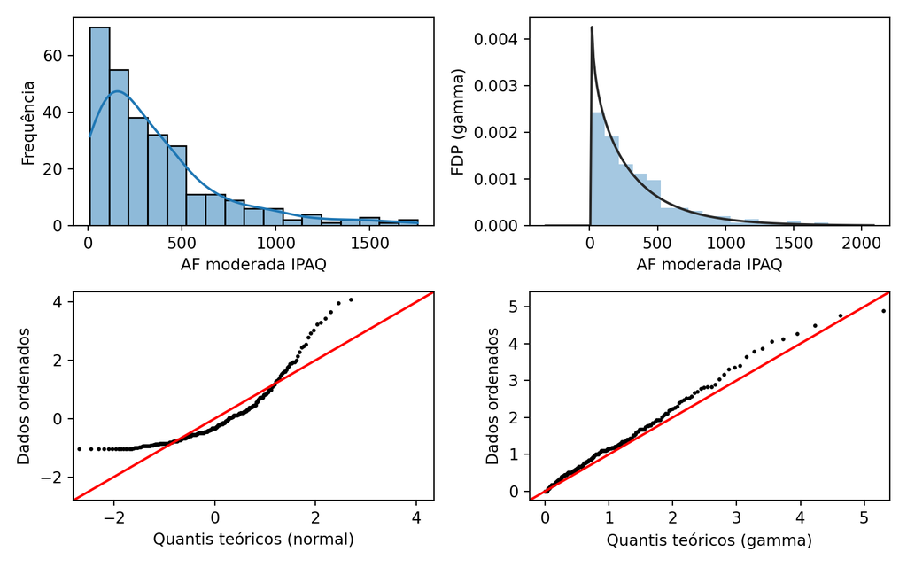

```python
fig, ((ax1,ax2), (ax3,ax4)) = plt.subplots(nrows = 2, ncols = 2, figsize=(8,5), sharey=False)

sns.histplot(mod_IPAQ, kde=True, ax=ax1)
ax1.set_xlabel('AF moderada IPAQ')
sns.distplot(mod_IPAQ, fit=stats.gamma, kde=False, ax=ax2)
ax2.set_xlabel('AF moderada IPAQ')
ax1.set_ylabel('Frequência')
ax2.set_ylabel('FDP (gamma)')

pp = sm.ProbPlot(df_mod_ipaq.Moderada_IPAQ_10, dist=scipy.stats.distributions.norm, fit=True)
qq = pp.qqplot(marker='.', markerfacecolor='k', markeredgecolor='k', markersize=3, ax=ax3)
sm.qqline(qq.axes[2], line='45')
ax3.set_ylabel('Dados ordenados')
ax3.set_xlabel('Quantis teóricos (normal)')
pp = sm.ProbPlot(df_mod_ipaq.Moderada_IPAQ_10, dist=stats.gamma, fit=True)
qq = pp.qqplot(marker='.', markerfacecolor='k', markeredgecolor='k', markersize=3, ax=ax4)
sm.qqline(qq.axes[3], line='45')
ax4.set_ylabel('Dados ordenados')
ax4.set_xlabel('Quantis teóricos (gamma)')


plt.rcParams['axes.labelsize']=12
plt.rcParams['axes.titlesize']=12


plt.tight_layout()
#plt.savefig('D:/Projeto_mestrado/Dissertacao/MastersDissertation/Análise exploratória/Distribuição das VDs/Gráficos/distribuicao_moderada_ipaq_sem_outliers_z_score.png', bbox_inches='tight', dpi = 300)
plt.show()
```

#### Vigorosa IPAQ

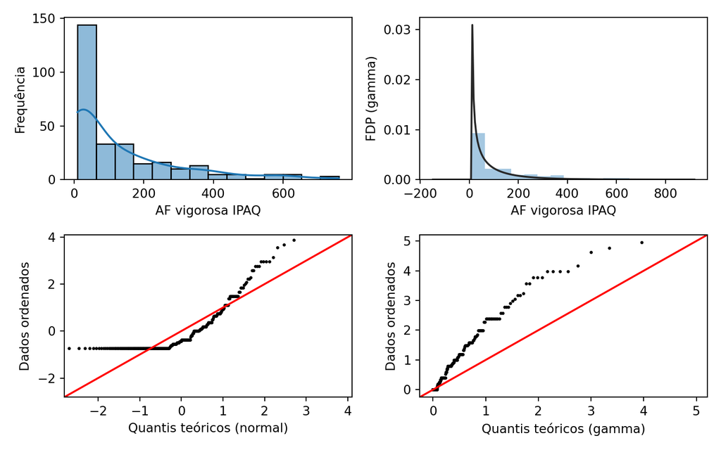

```python
fig, ((ax1,ax2), (ax3,ax4)) = plt.subplots(nrows = 2, ncols = 2, figsize=(8,5), sharey=False)

sns.histplot(vig_IPAQ, kde=True, ax=ax1)
ax1.set_xlabel('AF vigorosa IPAQ')
sns.distplot(vig_IPAQ, fit=stats.gamma, kde=False, ax=ax2)
ax2.set_xlabel('AF vigorosa IPAQ')
ax1.set_ylabel('Frequência')
ax2.set_ylabel('FDP (gamma)')

pp = sm.ProbPlot(df_vig_ipaq.Vigorosa_IPAQ_10, dist=scipy.stats.distributions.norm, fit=True)
qq = pp.qqplot(marker='.', markerfacecolor='k', markeredgecolor='k', markersize=3, ax=ax3)
sm.qqline(qq.axes[2], line='45')
ax3.set_ylabel('Dados ordenados')
ax3.set_xlabel('Quantis teóricos (normal)')
pp = sm.ProbPlot(df_vig_ipaq.Vigorosa_IPAQ_10, dist=stats.gamma, fit=True)
qq = pp.qqplot(marker='.', markerfacecolor='k', markeredgecolor='k', markersize=3, ax=ax4)
sm.qqline(qq.axes[3], line='45')
ax4.set_ylabel('Dados ordenados')
ax4.set_xlabel('Quantis teóricos (gamma)')


plt.rcParams['axes.labelsize']=12
plt.rcParams['axes.titlesize']=12


plt.tight_layout()
#plt.savefig('D:/Projeto_mestrado/Dissertacao/MastersDissertation/Análise exploratória/Distribuição das VDs/Gráficos/distribuicao_vigorosa_ipaq_sem_outliers_z_score.png', bbox_inches='tight', dpi = 300)
plt.show()
```

## Dados do FLEEM System

### Importar banco de dados

```python
dados = pd.read_excel('D:/Projeto_mestrado/Dissertacao/MastersDissertation/Dados/Quinto processamento/banco_dados_reestruturado.xlsx')
```

### Agora, vamos remover os dados faltantes, pois estes podem impactar na nossa inspeção. Para isso, usei a função dropna()

```python
dados = dados.dropna()
```

### Salvar os dados do FLEEM em uma variável, framentado em intensidades de AF

```python
leve_FLEEM = list(dados['Leve_FLEEM'].values)
levefleem_p_quartil_dados = pd.DataFrame(dados['Leve_FLEEM'])

mod_FLEEM = list(dados['Moderada_FLEEM_10'].values)
modfleem_p_quartil_dados = pd.DataFrame(dados['Moderada_FLEEM_10'])

vig_FLEEM = list(dados['Vigorosa_FLEEM_10'].values)
vigfleem_p_quartil_dados = pd.DataFrame(dados['Vigorosa_FLEEM_10'])
```

Agora vamos calcular os percentis dos dados

### Leve FLEEM

```python
df_leve_fleem = levefleem_p_quartil_dados.sort_values(by=['Leve_FLEEM'], ascending=True).reset_index()
df_leve_fleem['count'] = df_leve_fleem.index + 1
n_rows = df_leve_fleem.shape[0]
df_leve_fleem['percentil_area'] = (df_leve_fleem['count'])/n_rows
df_leve_fleem['percentil_teorico'] = ndtri(df_leve_fleem['percentil_area'])
df_leve_fleem['percentil_atual'] = (df_leve_fleem['Leve_FLEEM'] - df_leve_fleem['Leve_FLEEM'].mean())/df_leve_fleem['Leve_FLEEM'].std(ddof=0)
```

### Moderada FLEEM

```python
df_mod_fleem = modfleem_p_quartil_dados.sort_values(by=['Moderada_FLEEM_10'], ascending=True).reset_index()
df_mod_fleem['count'] = df_mod_fleem.index + 1
n_rows = df_mod_fleem.shape[0]
df_mod_fleem['percentil_area'] = (df_mod_fleem['count'])/n_rows
df_mod_fleem['percentil_teorico'] = ndtri(df_mod_fleem['percentil_area'])
df_mod_fleem['percentil_atual'] = (df_mod_fleem['Moderada_FLEEM_10'] - df_mod_fleem['Moderada_FLEEM_10'].mean())/df_mod_fleem['Moderada_FLEEM_10'].std(ddof=0)
```

### Vigorosa FLEEM

```python
df_vig_fleem = vigfleem_p_quartil_dados.sort_values(by=['Vigorosa_FLEEM_10'], ascending=True).reset_index()
df_vig_fleem['count'] = df_vig_fleem.index + 1
n_rows = df_vig_fleem.shape[0]
df_vig_fleem['percentil_area'] = (df_vig_fleem['count'])/n_rows
df_vig_fleem['percentil_teorico'] = ndtri(df_vig_fleem['percentil_area'])
df_vig_fleem['percentil_atual'] = (df_vig_fleem['Vigorosa_FLEEM_10'] - df_vig_fleem['Vigorosa_FLEEM_10'].mean())/df_vig_fleem['Vigorosa_FLEEM_10'].std(ddof=0)
```

### Agora vamos testar as distribuições por bruteforce

#### Leve FLEEM

```python
dist = distfit(alpha=0.05, smooth=10)

d = np.array(levefleem_p_quartil_dados)


dist.fit_transform(d)
```

```python
best_distr = dist.model
```

```python
dist.summary
```

```
##           name     score  ... bootstrap_pass    color
## 0      uniform       0.0  ...           None  #e41a1c
## 1         beta       0.0  ...           None  #e41a1c
## 2        gamma       0.0  ...           None  #377eb8
## 3            t       0.0  ...           None  #4daf4a
## 4         norm       0.0  ...           None  #984ea3
## 5     loggamma       0.0  ...           None  #ff7f00
## 6     dweibull       0.0  ...           None  #ffff33
## 7       pareto       0.0  ...           None  #a65628
## 8        expon       0.0  ...           None  #f781bf
## 9   genextreme       0.0  ...           None  #999999
## 10     lognorm  0.000001  ...           None  #999999
##
## [11 rows x 10 columns]
```

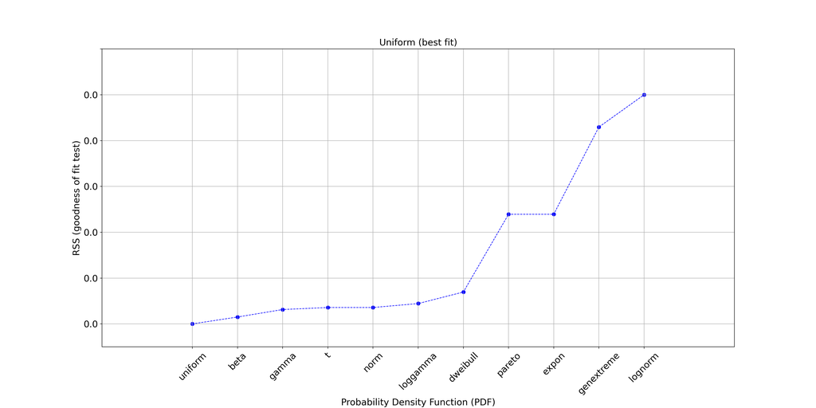

```python
dist.plot_summary()
```

A partir da análise acima, temos como distribuições candidatas, a normal e a Gamma.

#### Moderada FLEEM

```python
dist = distfit(alpha=0.05, smooth=10)

e = np.array(modfleem_p_quartil_dados)


dist.fit_transform(e)
```

```python
best_distr = dist.model
```

```python
dist.summary
```

```
##           name     score            loc  ... bootstrap_score bootstrap_pass    color
## 0      uniform  0.000002           10.0  ...               0           None  #e41a1c
## 1         beta  0.000004      -27.57826  ...               0           None  #e41a1c
## 2     loggamma  0.000005   -40566.15798  ...               0           None  #377eb8
## 3         norm  0.000005     287.321767  ...               0           None  #4daf4a
## 4            t  0.000005     287.322931  ...               0           None  #984ea3
## 5        gamma  0.000006    -333.900134  ...               0           None  #ff7f00
## 6      lognorm  0.000006    -742.426448  ...               0           None  #ffff33
## 7     dweibull  0.000006     285.910723  ...               0           None  #a65628
## 8       pareto   0.00001 -17179869174.0  ...               0           None  #f781bf
## 9        expon   0.00001           10.0  ...               0           None  #999999
## 10  genextreme  0.000017      12.582509  ...               0           None  #999999
##
## [11 rows x 10 columns]
```

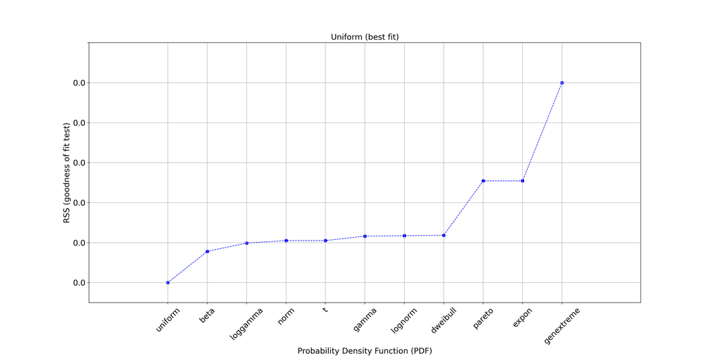

```python
dist.plot_summary()
```

Distribuições candidatas: normal, gamma e loggamma

#### Vigorosa FLEEM

```python
dist = distfit(alpha=0.05, smooth=10)

f = np.array(vigfleem_p_quartil_dados)


dist.fit_transform(f)
```

```python
best_distr = dist.model
```

```python
dist.summary
```

```
##           name     score           loc  ... bootstrap_score bootstrap_pass    color
## 0     loggamma  0.000003 -29975.105154  ...               0           None  #e41a1c
## 1         norm  0.000004    107.066246  ...               0           None  #e41a1c
## 2     dweibull  0.000016     84.538861  ...               0           None  #377eb8
## 3      uniform  0.000031          10.0  ...               0           None  #4daf4a
## 4            t  0.000031     77.754778  ...               0           None  #984ea3
## 5        expon  0.000059          10.0  ...               0           None  #ff7f00
## 6       pareto  0.000059 -1073741814.0  ...               0           None  #ffff33
## 7         beta  0.000059          10.0  ...               0           None  #a65628
## 8        gamma  0.000061          10.0  ...               0           None  #f781bf
## 9   genextreme  0.000068     53.985638  ...               0           None  #999999
## 10     lognorm  0.000075       1.74439  ...               0           None  #999999
##
## [11 rows x 10 columns]
```

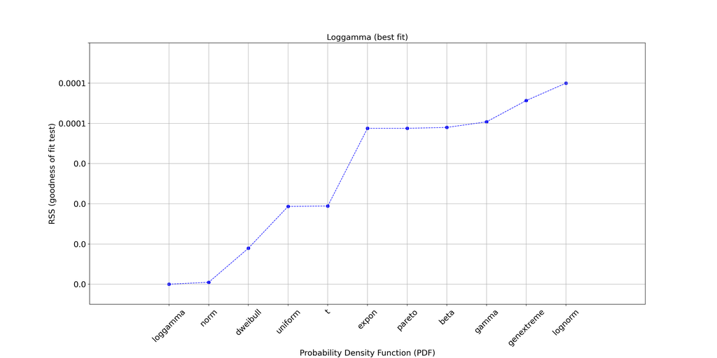

```python
dist.plot_summary()
```

Distribuições candidatas: normal e loggamma

Agora, vamos construir subplots com um gráfico quantil-quantil, para analisarmos melhor as possíveis distribuições de probabilidade para os nossos modelos

#### Leve FLEEM

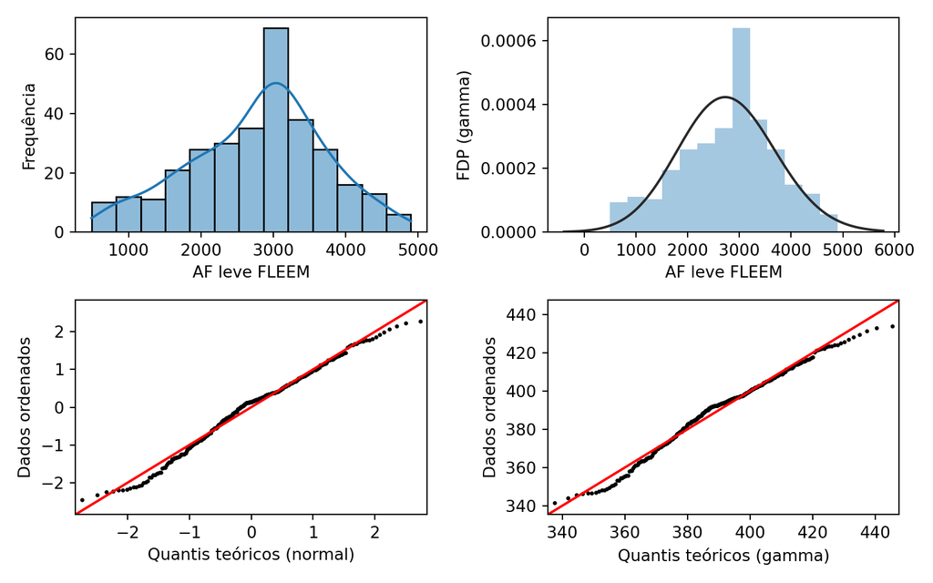

```python
fig, ((ax1,ax2), (ax3,ax4)) = plt.subplots(nrows = 2, ncols = 2, figsize=(8,5), sharey=False)

sns.histplot(leve_FLEEM, kde=True, ax=ax1)
ax1.set_xlabel('AF leve FLEEM')
sns.distplot(leve_FLEEM, fit=stats.gamma, kde=False, ax=ax2)
ax2.set_xlabel('AF leve FLEEM')
ax1.set_ylabel('Frequência')
ax2.set_ylabel('FDP (gamma)')

pp = sm.ProbPlot(df_leve_fleem.Leve_FLEEM, dist=scipy.stats.distributions.norm, fit=True)
qq = pp.qqplot(marker='.', markerfacecolor='k', markeredgecolor='k', markersize=3, ax=ax3)
sm.qqline(qq.axes[2], line='45')
ax3.set_ylabel('Dados ordenados')
ax3.set_xlabel('Quantis teóricos (normal)')
pp = sm.ProbPlot(df_leve_fleem.Leve_FLEEM, dist=stats.gamma, fit=True)
qq = pp.qqplot(marker='.', markerfacecolor='k', markeredgecolor='k', markersize=3, ax=ax4)
sm.qqline(qq.axes[3], line='45')
ax4.set_ylabel('Dados ordenados')
ax4.set_xlabel('Quantis teóricos (gamma)')


plt.rcParams['axes.labelsize']=12
plt.rcParams['axes.titlesize']=12


plt.tight_layout()
#plt.savefig('D:/Projeto_mestrado/Dissertacao/MastersDissertation/Análise exploratória/Distribuição das VDs/Gráficos/distribuicao_leve_fleem.png', bbox_inches='tight', dpi = 300)
plt.show()
```

#### Moderada FLEEM

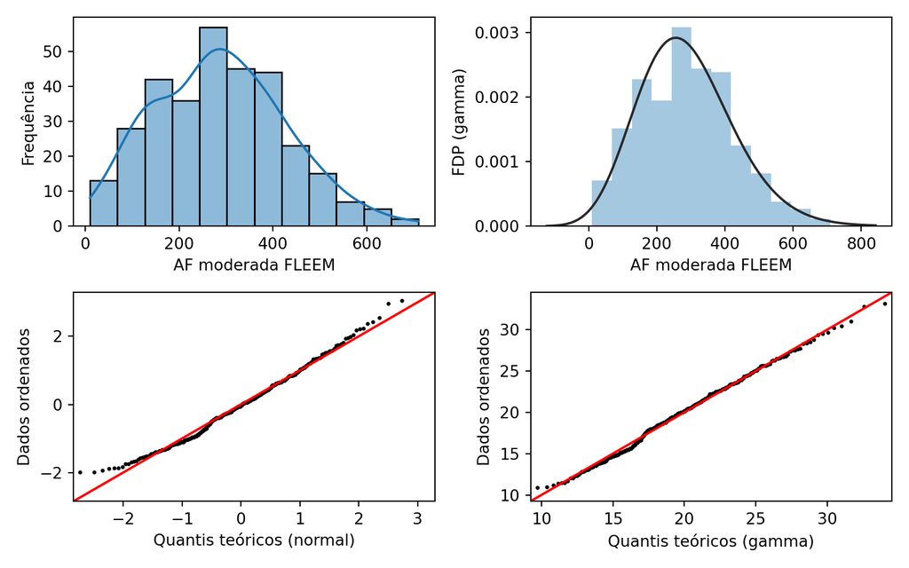

```python
fig, ((ax1,ax2), (ax3,ax4)) = plt.subplots(nrows = 2, ncols = 2, figsize=(8,5), sharey=False)

sns.histplot(mod_FLEEM, kde=True, ax=ax1)
ax1.set_xlabel('AF moderada FLEEM')
sns.distplot(mod_FLEEM, fit=stats.gamma, kde=False, ax=ax2)
ax2.set_xlabel('AF moderada FLEEM')
ax1.set_ylabel('Frequência')
ax2.set_ylabel('FDP (gamma)')

pp = sm.ProbPlot(df_mod_fleem.Moderada_FLEEM_10, dist=scipy.stats.distributions.norm, fit=True)
qq = pp.qqplot(marker='.', markerfacecolor='k', markeredgecolor='k', markersize=3, ax=ax3)
sm.qqline(qq.axes[2], line='45')
ax3.set_ylabel('Dados ordenados')
ax3.set_xlabel('Quantis teóricos (normal)')
pp = sm.ProbPlot(df_mod_fleem.Moderada_FLEEM_10, dist=stats.gamma, fit=True)
qq = pp.qqplot(marker='.', markerfacecolor='k', markeredgecolor='k', markersize=3, ax=ax4)
sm.qqline(qq.axes[3], line='45')
ax4.set_ylabel('Dados ordenados')
ax4.set_xlabel('Quantis teóricos (gamma)')


plt.rcParams['axes.labelsize']=12
plt.rcParams['axes.titlesize']=12


plt.tight_layout()
#plt.savefig('D:/Projeto_mestrado/Dissertacao/MastersDissertation/Análise exploratória/Distribuição das VDs/Gráficos/distribuicao_moderada_fleem.png', bbox_inches='tight', dpi = 300)
plt.show()
```

#### Vigorosa FLEEM

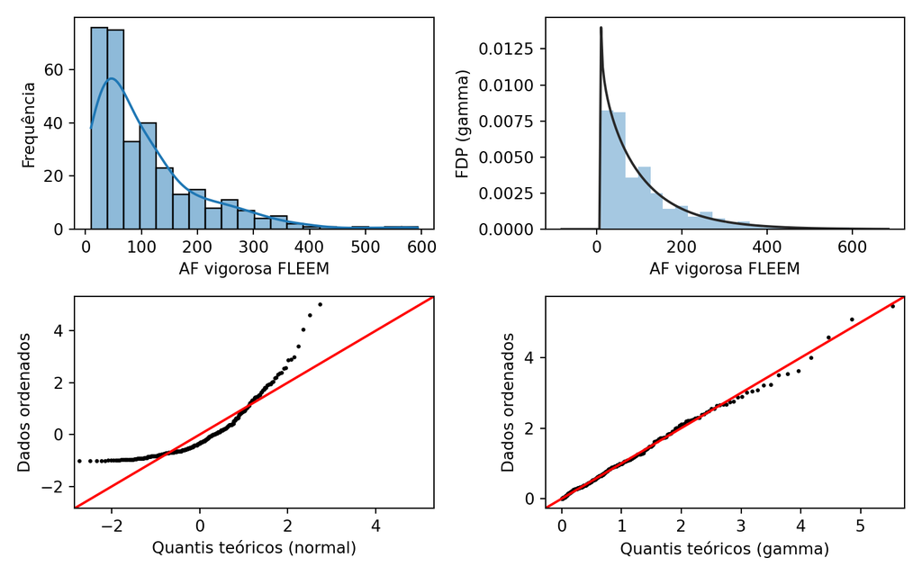

```python
fig, ((ax1,ax2), (ax3,ax4)) = plt.subplots(nrows = 2, ncols = 2, figsize=(8,5), sharey=False)

sns.histplot(vig_FLEEM, kde=True, ax=ax1)
ax1.set_xlabel('AF vigorosa FLEEM')
sns.distplot(vig_FLEEM, fit=stats.gamma, kde=False, ax=ax2)
ax2.set_xlabel('AF vigorosa FLEEM')
ax1.set_ylabel('Frequência')
ax2.set_ylabel('FDP (gamma)')

pp = sm.ProbPlot(df_vig_fleem.Vigorosa_FLEEM_10, dist=scipy.stats.distributions.norm, fit=True)
qq = pp.qqplot(marker='.', markerfacecolor='k', markeredgecolor='k', markersize=3, ax=ax3)
sm.qqline(qq.axes[2], line='45')
ax3.set_ylabel('Dados ordenados')
ax3.set_xlabel('Quantis teóricos (normal)')
pp = sm.ProbPlot(df_vig_fleem.Vigorosa_FLEEM_10, dist=stats.gamma, fit=True)
qq = pp.qqplot(marker='.', markerfacecolor='k', markeredgecolor='k', markersize=3, ax=ax4)
sm.qqline(qq.axes[3], line='45')
ax4.set_ylabel('Dados ordenados')
ax4.set_xlabel('Quantis teóricos (gamma)')


plt.rcParams['axes.labelsize']=12
plt.rcParams['axes.titlesize']=12


plt.tight_layout()
#plt.savefig('D:/Projeto_mestrado/Dissertacao/MastersDissertation/Análise exploratória/Distribuição das VDs/Gráficos/distribuicao_vigorosa_fleem.png', bbox_inches='tight', dpi = 300)
plt.show()
```